# task_NN_empty (2)

```python
from collections import defaultdict
from collections import OrderedDict
import torch
from torch import nn
from torch.utils.data import Dataset
import numpy as np
import matplotlib.pyplot as plt
%matplotlib inline

import seaborn as sns
sns.set(palette='Set2', font_scale=1.2)

from IPython.display import clear_output
from sklearn.datasets import load_boston
```

[output not shown]

```python
boston = load_boston()
boston['data'];
boston['target'];
```

[output not shown]

#### Сформируем тренировочную и валидационную выборки

```python
np.random.seed(1)
indeces = np.arange(len(boston.target))
np.random.shuffle(indeces)
```

```python
train_ind = indeces[:int(len(indeces) * 0.8)]
test_ind = indeces[int(len(indeces) * 0.2):]
```

#### Выбор признака

Для выбора обучим случайный лес на датасете и с помощью него посмотрим важность признаков. В качестве второго выберем признак с наибольшей статистической значимостью

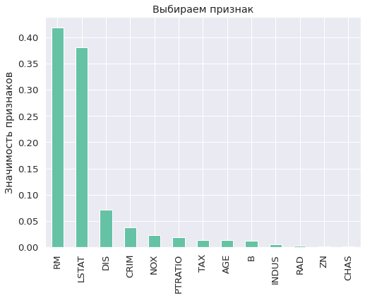

```python
from sklearn.datasets import make_classification
from sklearn.model_selection import train_test_split

from sklearn.ensemble import RandomForestRegressor
import pandas as pd

forest = RandomForestRegressor(random_state=12)
forest.fit(boston.data, boston.target) #Обучим случайный лес на всей выборке

feature_importance = pd.Series(forest.feature_importances_, boston.feature_names).sort_values(ascending=False)
plt.figure(figsize = (8,6))
feature_importance.plot(kind='bar', title='Выбираем признак')
plt.ylabel('Значимость признаков');
```

Берем признак RM. Это 6 признак.

#### Далее сформируйте датасет в pytorch-обертке

```python
class BostonDataset(Dataset):
    def __init__(self, boston_dataset, indeces, train_split_ratio, train: bool):
        self.indeces = indeces
        self.train_split_ratio = train_split_ratio
        self.train = train

        self.ll = len(boston_dataset.data)
        train_ind = self.indeces[:int(self.ll * self.train_split_ratio)]
        test_ind = self.indeces[int(self.ll * self.train_split_ratio):]

        if train:
            self.data = boston_dataset.data[:, [-1,5]][train_ind]
            self.labels = boston_dataset.target[train_ind]
        else:
            self.data = boston_dataset.data[:, [-1,5]][test_ind]
            self.labels = boston_dataset.target[test_ind]

    def __len__(self):
        return len(self.labels)

    def __getitem__(self, idx):
        sample = self.data[idx]/10
        label = self.labels[idx]
        return sample, label
```

```python
trainset = BostonDataset(boston, train_ind, 1, True)
testset = BostonDataset(boston, test_ind, 0, False)
```

#### Создайте и обучите нейросеть

Делаем нейросеть как на семинаре

Для начала разбиваем нашу выборку на батчи

```python
batch_size = 202

trainloader = torch.utils.data.DataLoader(trainset,
                                          batch_size=batch_size,
                                          shuffle=True)

testloader = torch.utils.data.DataLoader(testset,
                                         batch_size= testset.__len__(),
                                         shuffle=False)
```

Теперь пишем саму модель. Чтобы понять, какие слои стоит добавить, посмотрим как выглядят данные.

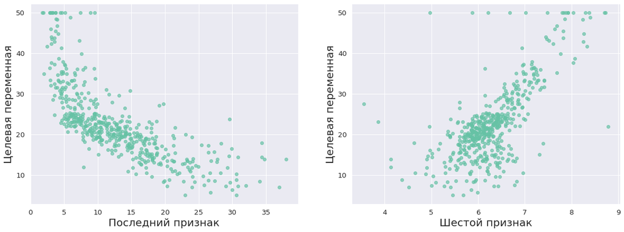

```python
fig = plt.figure(figsize=(20,7))

ax = fig.add_subplot(1,2,1)
ax.scatter(boston.data[:, -1], boston.target, alpha=0.7)
ax.set_xlabel('Последний признак', fontsize = 20)
ax.set_ylabel('Целевая переменная', fontsize = 20)

ax = fig.add_subplot(1,2,2)
ax.scatter(boston.data[:, 5], boston.target, alpha=0.7)
ax.set_xlabel('Шестой признак', fontsize = 20)
ax.set_ylabel('Целевая переменная', fontsize = 20);
```

Видно, что подойдут слои с семинара

```python
torch.manual_seed(2)
# Создаем последовательную нейронную сеть
model = nn.Sequential()

# Добавляем линейный слой с выходным размером 1.
# Размер входа равен произведению размерностей данных.
model.add_module('linear_1', nn.Linear(2, 3))
model.add_module('relu_', nn.ReLU())
model.add_module('linear_2', nn.Linear(3, 1))
```

В качестве критерия возьмём MSE

```python
criterion = nn.MSELoss()
```

Инициализируем веса

```python
# функция для инициализаци весов
def init_weights(model):
    if isinstance(model, nn.Linear):
        torch.nn.init.normal_(model.weight)

# Инициализация весов
model.apply(init_weights)
```

```
Sequential(
  (linear_1): Linear(in_features=2, out_features=3, bias=True)
  (relu_): ReLU()
  (linear_2): Linear(in_features=3, out_features=1, bias=True)
)
```

Переводим модель на GPU

```python
device = 'cuda:0'
model.to(device);
```

Возьмём SGD в качестве оптимизатора

```python
opt = torch.optim.SGD(model.parameters(), lr=0.005)
```

Теперь обучим нашу нейронную сеть. Посмотрим на графики и лосс.

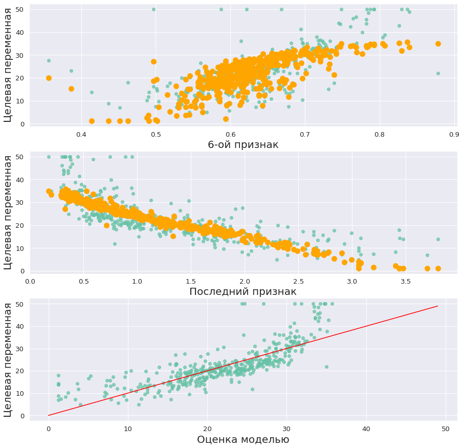

```python
num_epochs = 100  # общее кол-во полных проходов ("эпох") по обучаемым данным

num_train_batches = (trainset.__len__()) // batch_size
num_val_batches = 1 # так как для валидационного набора батч - вся выборка (мы так задали размер батча)

history = defaultdict(lambda: defaultdict(list))

for epoch in range(num_epochs):
    print(f'epoch {epoch}')

    train_loss = 0
    val_loss = 0


    # Устанавливаем режим обучения
    model.train(True)

    # На каждой "эпохе" делаем полный проход по данным
    for _, data in enumerate(trainloader):

        X_batch = data[0].to(device).float()
        y_batch = torch.unsqueeze(data[1].to(device), 1).float()

        # Обучаемся на батче (одна "итерация" обучения нейросети)
        outs = model(X_batch)
        loss = criterion(outs, y_batch)

        # Обратный проход, шаг оптимизатора и зануление градиентов
        loss.backward()

        opt.step()
        opt.zero_grad()


        train_loss += loss.detach().cpu().numpy()
        y_pred_np = outs.detach().cpu().numpy()
        y_batch_np = y_batch.cpu().numpy()

    # Подсчитываем лоссы и сохраням в "историю"
    train_loss /= num_train_batches
    history['loss']['train'].append(train_loss)

    # Устанавливаем режим тестирования
    model.eval()

    # Полный проход по валидации
    with torch.no_grad(): # Отключаем подсчет градиентов, то есть detach не нужен
        for _, data_test in enumerate(testloader):
            X_batch = data_test[0].to(device).float()
            #X_batch = torch.unsqueeze(X_batch, 1).float()
            y_batch = torch.unsqueeze(data_test[1].to(device).float(), 1)

            outs = model(X_batch)
            loss = criterion(outs, y_batch)

            val_loss += loss.cpu().numpy().sum()
            y_pred_np = outs.cpu().numpy()
            y_batch_np = y_batch.cpu().numpy()

    # Подсчитываем лоссы и сохраням в "историю"
    val_loss /= num_val_batches
    history['loss']['val'].append(val_loss)

    # График + вывод лосса
    clear_output(True)
    fig, ax = plt.subplots(3, 1, figsize = (15, 15))

    ax[0].scatter(X_batch[:,1].cpu().numpy(), y_batch.cpu().data.numpy(), alpha=0.75)
    ax[0].scatter(X_batch[:,1].cpu().numpy(), y_pred_np, color='orange', linewidth=5)
    ax[0].set_xlabel('6-ой признак', fontsize = 20)
    ax[0].set_ylabel('Целевая переменная', fontsize = 20)

    ax[1].scatter(X_batch[:,0].cpu().numpy(), y_batch.cpu().data.numpy(), alpha=0.75)
    ax[1].scatter(X_batch[:,0].cpu().numpy(), y_pred_np, color='orange', linewidth=5)
    ax[1].set_xlabel('Последний признак', fontsize = 20)
    ax[1].set_ylabel('Целевая переменная', fontsize = 20)

    ax[2].scatter(y_pred_np, y_batch.cpu().data.numpy(),  alpha=0.75)
    ax[2].plot(np.arange(y_batch.cpu().max()), np.arange(y_batch.cpu().max()),  color = 'red')
    ax[2].set_xlabel('Оценка моделью', fontsize = 20)
    ax[2].set_ylabel('Целевая переменная', fontsize = 20)

    plt.show()
```

Посмотрим на кривую обучения

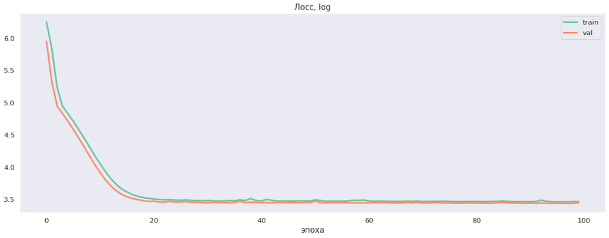

```python
fig = plt.figure(figsize=(20,7))

plt.subplot(1,1,1)
plt.title('Лосс, log', fontsize=15)
plt.plot(np.log(history['loss']['train']), label='train', linewidth = 3)
plt.plot(np.log(history['loss']['val']), label='val', linewidth = 3)
plt.grid()
plt.xlabel('эпоха', fontsize=15)
plt.legend();
```

#### Задача 2

С начало разберемся, какие вообще есть гиперпараметры: manual_seed, размеры train/test выборок, batch_size, слои нейросети, начальная инициализация, количество эпох, оптимизатор и его параметры, . Рассмотрим каждый по отдельности.

1)Manual_seed - случайный параметр. Нет смысла рассматривать его как гиперпараметр.

2)Размеры выборок играют только на силу переобучения и значения лоса, не так сильно на веса модели. Данные параметры можно выбрать из качественных соображений, рассматривать их дальше тоже не буедм.

3)От batch_size зависит только время/вычислительная сложность работы. Сколько в итоге вся выборка пройдёт через нейросеть определяется не этим параметром, следовательно, на веса он тоже не влияет.

4)Слои нейрости должны тоже выбираться из качественных соображений. Исследовать их как гиперпараметр, особенно в такой простой задаче, где, по-сути, любые слои дадут правильный ответ - глупо.

5)Начальная инициализация, если он плохая, может привести нас не в глобальный, а локальный минимум, например. Но, если, всё-таки, этого не случается, то менять её тоже не стоит и от неё мало чего зависит

6)Количество эпох также не очень важный параметр. Надо просто поставить критерий остановки, при котором наши итирации закончатся, а количество эпох делать достаточно большим. Поэтому, рассматривать как гиперпараметр это тоже не будем.

7)Оптимизатор и его параметры сильно вляют на результат, в чем я убедился в предыдущей задаче. Как видно из пункта 4 задачи три мне даже удалось переобучить двухслойную нейронную сеть, неправильно выбрав оптимизатор и его параметр. Главный параметр оптимизатора SGD - learning rate. Посмотрим как он влияет на результаты модели.

```python
#Собрал весь код, чтобы увидеть весь пайплан сразу
#Train и test выборка
trainset = BostonDataset(boston, train_ind, 1, True)
testset = BostonDataset(boston, test_ind, 0, False)
#Батчи
batch_size = 202
trainloader = torch.utils.data.DataLoader(trainset, batch_size=batch_size, shuffle=True)
testloader = torch.utils.data.DataLoader(testset, batch_size= testset.__len__(), shuffle=False)
torch.manual_seed(2)
# Создаем последовательную нейронную сеть
model = nn.Sequential()
# Добавляем линейный слой с выходным размером 1.
# Размер входа равен произведению размерностей данных.
model.add_module('linear_1', nn.Linear(2, 3))
model.add_module('relu_', nn.ReLU())
model.add_module('linear_2', nn.Linear(3, 1))
criterion = nn.MSELoss()
# Инициализация весов
model.apply(init_weights)
#Переход на cuda
model.to(device)
#Обучаем нейросеть
num_epochs = 100  # общее кол-во полных проходов ("эпох") по обучаемым данным
num_train_batches = (trainset.__len__()) // batch_size #Количество train батчей
num_val_batches = 1 #Кол-во тест батчей
MSE = np.zeros((50,100)) #Создаём пустой массив MSE, чтобы потом посмотреть на зависимости

for i, lr in enumerate(np.linspace(0,1,50)):
  history = defaultdict(lambda: defaultdict(list)) #Каждый раз нужна чистая история
  #Выбор оптимизатора
  opt = torch.optim.SGD(model.parameters(), lr=lr)

  for epoch in range(num_epochs):
      train_loss = 0
      val_loss = 0
      # Устанавливаем режим обучения
      model.train(True)
      # На каждой "эпохе" делаем полный проход по данным
      for _, data in enumerate(trainloader):
          X_batch = data[0].to(device).float()
          y_batch = torch.unsqueeze(data[1].to(device), 1).float()
          # Обучаемся на батче (одна "итерация" обучения нейросети)
          outs = model(X_batch)
          loss = criterion(outs, y_batch)
          # Обратный проход, шаг оптимизатора и зануление градиентов
          loss.backward()
          opt.step()
          opt.zero_grad()

          train_loss += loss.detach().cpu().numpy()
          y_pred_np = outs.detach().cpu().numpy()
          y_batch_np = y_batch.cpu().numpy()

      # Подсчитываем лоссы и сохраням в "историю"
      train_loss /= num_train_batches
      history['loss']['train'].append(train_loss)

      # Устанавливаем режим тестирования
      model.eval()

      # Полный проход по валидации
      with torch.no_grad(): # Отключаем подсчет градиентов, то есть detach не нужен
          for _, data_test in enumerate(testloader):
              X_batch = data_test[0].to(device).float()
              y_batch = torch.unsqueeze(data_test[1].to(device).float(), 1)
              outs = model(X_batch)
              loss = criterion(outs, y_batch)
              val_loss += loss.cpu().numpy().sum()
              y_pred_np = outs.cpu().numpy()
              y_batch_np = y_batch.cpu().numpy()
      # Подсчитываем лоссы и сохраням в "историю"
      val_loss /= num_val_batches
      history['loss']['val'].append(val_loss)
  MSE[i] = np.array(history['loss']['val'])
```

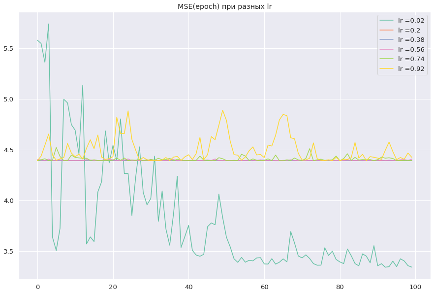

```python
plt.figure(figsize=(15,10))
for i in range(1,50,9):
  plt.plot([i for i in range(100)], np.log(MSE[i]), label = 'lr =' + str(i * 1 / 50))
plt.title('MSE(epoch) при разных lr')
plt.legend();
```

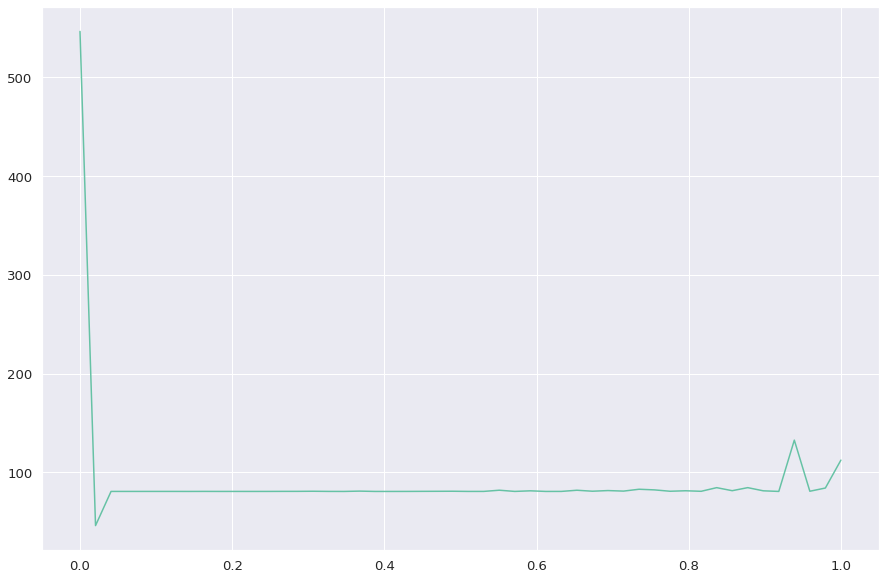

```python
plt.figure(figsize = (15,10))
plt.plot(np.linspace(0,1,50),MSE[:,49], label = 'MSE(lr)');
```

Из очевидного - лосс при нулевом LR очень высок, а при LR->1 начинает расти из-за переобучения. В определенном интервале лосс почти не меняется, что связано с тем, что за 100 эпох наша сеть попадает в локальный экстремум при любой LR в данном интервале. Виден отчетливый минимум в области нуля. Следовательно, при определенном значении LR наша модель попадет не в локальный, а глобальный экстремум.

#### Задача 3

1. Переобучение - подгон под тренировочную выборку. Существует классический пример с многочленами. Допустим, у нас есть 10 точек, которые лежат примерно на одной прямой. Логично было бы профитировать прямую. Но можно профитировать многочлен 10 степени. В итоге, на тренировочной выборке точность будет 100%, но, очвеидно, если добавить пару точек, наш многочлен даст очень плохой результат.
2. Оно может произойти при неправильном выборе модели(можно взять слишком сложную модель) и сильном подгоне под тренировочную выборку(высокий лернинг рейт).
3. Нет, не всегда. Если у нас уже выбрана модель, то может быть такое, что она просто не может идеально выдавать значения такие же, как на трейне(просто по формуле).
4. Да. Просто добавить столько слоёв, сколько всего точек, например. Но даже это не обязательно. Поставив слишком высокий лернинг рейт в первой задаче получил следующее.

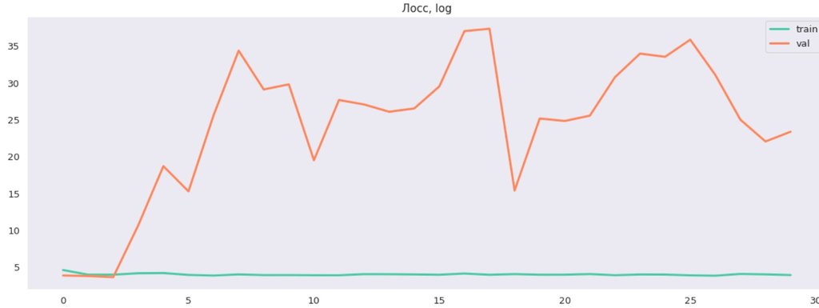